# E-commerce business data analysis

### by Lorena Peñuela Cantor

### [Website](https://lpenuelac.github.io)

# **Content**

1. Introduction
2. Goal
3. Collaboration Plan
4. Datasets
5. Exploratory data analysis
6. Customers location
7. Sellers location
8. First question
9. Orders
10. Second question
11. Model
12. KNN
13. Lasso
14. Conclusion

# **Introduction**

The brazilian company [Olist](https://olist.com/pt-br/) is an e-commerce that specializes in the fields of logistics and capital. Olist is leading the way as the #1 commerce enabler for Small business in Brazil, now expanding globally.

The company started with a single core connecting merchants to marketplaces and evolved to a complete ecosystem of integrated products in 3 dimensions: Commerce, Logistics, and Capital.

# **Goal**

The main goal of this project is to use the data from [Olist](https://olist.com/pt-br/) to identify buying patterns that allow generating knowledge about its operations and add value to the business; through the extraction, analysis, and visualization of data.

# **Collaboration Plan**

This work will be carried out solely by me as a master's student, based on what I learned in the Introduction to Data Science classes and the feedback received by Dr. Nicholas Mattei as professor of the course.

This project is developed using python as programming language, Google Colab as development environment and GitHub as code repository and web server.

# **Datasets**

This dataset is in [Kaggle](https://www.kaggle.com/datasets/olistbr/brazilian-ecommerce) On the web page you can also find the data model, which is important to understand the relationship that exists between the different datasets.

[figure not shown]

There are eight datasets with the following data:

1. olist_order_payments_dataset: It includes the payment option and the number of installments if it is a credit card.
2. olist_orders_dataset: It relates all the information of an order, including delivery date, purchase date, and approved date.
3. olist_order_reviews_dataset: At the end of a purchase, Olist sends a customer survey that allows capturing the customer's satisfaction with their purchase. This information is stored in this dataset
4. olist_order_customer_dataset (as olist_customers_dataset): It stores data related to the customers and their locations as state, city and zip code.
5. olist_products_dataset: It stores data related to the products sold by Olist.
6. olist_order_items_dataset: An order could have more than one product. Then, this dataset stores all the products purchased in a order.
7. olist_sellers_dataset: It stores the data related to the sellers and their locations as state, city, and zip code.
8. olist_geolocation_dataset: It relates the Brazilian zip codes to latitude and longitude.

## **Exploratory data analysis**

One of the business questions that I would like to delve into is whether the location of customers and vendors affects sales or the products purchased, so I will mainly analyze the related data sets of customers and sellers as well as the datasets that allow them to be related. For this, it is necessary to know how the buyers are distributed, how the sellers are distributed, and how the delivered orders are distributed.

```python
#Reading the main datasets related to the bussiness question.
import pandas as pd
import matplotlib.pyplot as plt
customers = pd.read_csv("../data/olist_customers_dataset.csv")
sellers =  pd.read_csv("../data/olist_sellers_dataset.csv")
#This dataset is useful to make a map based geometries
#For the visualization, geopandas is required
# See how to install it https://geopandas.org/en/stable/getting_started/install.html
import geopandas as gpd
locations =  gpd.read_file("zip://../data/states.zip")
#Ignoring user warnings about KMeans memory leak
import warnings
warnings.filterwarnings('ignore')
import seaborn as sns
```

### **Customers Location**

```python
#The data availabe for the customers
customers.head(4)
```

|  | customer_id | customer_unique_id | customer_zip_code_prefix | customer_city | customer_state |
| --- | --- | --- | --- | --- | --- |
| 0 | 06b8999e2fba1a1fbc88172c00ba8bc7 | 861eff4711a542e4b93843c6dd7febb0 | 14409 | franca | SP |
| 1 | 18955e83d337fd6b2def6b18a428ac77 | 290c77bc529b7ac935b93aa66c333dc3 | 9790 | sao bernardo do campo | SP |
| 2 | 4e7b3e00288586ebd08712fdd0374a03 | 060e732b5b29e8181a18229c7b0b2b5e | 1151 | sao paulo | SP |
| 3 | b2b6027bc5c5109e529d4dc6358b12c3 | 259dac757896d24d7702b9acbbff3f3c | 8775 | mogi das cruzes | SP |

```python
customers.dtypes
```

```
customer_id                 object
customer_unique_id          object
customer_zip_code_prefix     int64
customer_city               object
customer_state              object
dtype: object
```

In this case, the customers have 5 variables and all of them are correctly identified.

```python
#The dataset doesn't have null or nan values
customers.isnull().count()
customers.isna().count()
```

```
customer_id                 99441
customer_unique_id          99441
customer_zip_code_prefix    99441
customer_city               99441
customer_state              99441
dtype: int64
```

An important feature of this dataset is that two identifiers are found. The `customer_id` represents an identifier of the client within the orders, that is to say, that a client can have several `customer_id` if she has made several orders, while she only has a `customer_unique_id`. So we are interested in knowing the number of customers of the company and if their location remains the same in each order

```python
#Total of rows in the customers dataframe
display("Number of no unique customers",customers.shape[0])
#Total of rows with unique id of the customers dataframe
display("Number of customers",len(pd.unique(customers["customer_unique_id"])))
```

```
'Number of no unique customers'
```

```
99441
```

```
'Number of customers'
```

```
96096
```

This means that about 3000 records refer to customers who have made repurchases

```python
#Getting the number number of ids (or orders) created by one user
customers_by_orders = customers.groupby("customer_unique_id").count()["customer_id"].reset_index(name='count') \
                             .sort_values(['count'], ascending=False)
#Customers who purchased one order
customers_one_order=customers_by_orders.loc[customers_by_orders["count"]==1]["customer_unique_id"]
display("customers who purchased one order")
display(customers_one_order)
# Obtaining clients who do not change their location
unduplicated_customers = customers[~customers.duplicated(subset=["customer_unique_id","customer_city","customer_zip_code_prefix","customer_state"],keep=False)]
display("unique customers")
display(unduplicated_customers)
# Removing customers of a single purchase to get customers who have different locations
customers_different_location = unduplicated_customers.loc[~unduplicated_customers["customer_unique_id"].isin(customers_one_order)]
display("customer with different locations")
display(customers_different_location)
```

```
'customers who purchased one order'
```

```
65416    adfdc84671ccd55dc3c4aa31b363bfb4
65652    ae9ae5072fe8d5b2a1f7072a833f0afc
64300    aaff146bd210808c7d004a05966472a7
65653    ae9b625c590bbfdd9e9ef836fbcbc7c9
65654    ae9b719375655dab3c518d76cc37a843
                       ...
32508    5657dfebff5868c4dc7e8355fea865c4
32507    5657596addb4d7b07b32cd330614bdf8
32506    5656eb169546146caeab56c3ffc3d268
32505    5656a8fabc8629ff96b2bc14f8c09a27
96095    ffffd2657e2aad2907e67c3e9daecbeb
Name: customer_unique_id, Length: 93099, dtype: object
```

```
'unique customers'
```

|  | customer_id | customer_unique_id | customer_zip_code_prefix | customer_city | customer_state |
| --- | --- | --- | --- | --- | --- |
| 0 | 06b8999e2fba1a1fbc88172c00ba8bc7 | 861eff4711a542e4b93843c6dd7febb0 | 14409 | franca | SP |
| 1 | 18955e83d337fd6b2def6b18a428ac77 | 290c77bc529b7ac935b93aa66c333dc3 | 9790 | sao bernardo do campo | SP |
| 2 | 4e7b3e00288586ebd08712fdd0374a03 | 060e732b5b29e8181a18229c7b0b2b5e | 1151 | sao paulo | SP |
| 3 | b2b6027bc5c5109e529d4dc6358b12c3 | 259dac757896d24d7702b9acbbff3f3c | 8775 | mogi das cruzes | SP |
| 4 | 4f2d8ab171c80ec8364f7c12e35b23ad | 345ecd01c38d18a9036ed96c73b8d066 | 13056 | campinas | SP |
| ... | ... | ... | ... | ... | ... |
| 99436 | 17ddf5dd5d51696bb3d7c6291687be6f | 1a29b476fee25c95fbafc67c5ac95cf8 | 3937 | sao paulo | SP |
| 99437 | e7b71a9017aa05c9a7fd292d714858e8 | d52a67c98be1cf6a5c84435bd38d095d | 6764 | taboao da serra | SP |
| 99438 | 5e28dfe12db7fb50a4b2f691faecea5e | e9f50caf99f032f0bf3c55141f019d99 | 60115 | fortaleza | CE |
| 99439 | 56b18e2166679b8a959d72dd06da27f9 | 73c2643a0a458b49f58cea58833b192e | 92120 | canoas | RS |
| 99440 | 274fa6071e5e17fe303b9748641082c8 | 84732c5050c01db9b23e19ba39899398 | 6703 | cotia | SP |

93582 rows × 5 columns

```
'customer with different locations'
```

|  | customer_id | customer_unique_id | customer_zip_code_prefix | customer_city | customer_state |
| --- | --- | --- | --- | --- | --- |
| 5 | 879864dab9bc3047522c92c82e1212b8 | 4c93744516667ad3b8f1fb645a3116a4 | 89254 | jaragua do sul | SC |
| 387 | 13e8265ea7e8a11df7a56799f5806220 | d55417a83a73d1702b43988e63f0731a | 8576 | itaquaquecetuba | SP |
| 453 | 302025f399c7405c509a297b6b9a1e73 | 7bf1c59401206e31a78523077f3a1144 | 6765 | taboao da serra | SP |
| 559 | 079da973ecd0fb654da4ffdb946c9ea1 | 527c6fbbe85cdf78ff1645e0a71e266f | 1455 | sao paulo | SP |
| 562 | 05425c98e35d762211742df2a2b30af0 | 87a7c3090f96d9da963125a0d7f8193a | 6114 | osasco | SP |
| ... | ... | ... | ... | ... | ... |
| 99182 | bafd51862cb88bd42d499170c2ac35fd | 408aee96c75632a92e5079eee61da399 | 22260 | rio de janeiro | RJ |
| 99227 | 1bd05d9a0031e8461d15550893d9b85a | 13abc50b97af7425b5066e405d7cd760 | 7793 | cajamar | SP |
| 99297 | 8b9f55ee19f0356ba6b3f03485e6922d | bc7b9e0d078c0c01f622b38cfcd7ee9c | 20521 | rio de janeiro | RJ |
| 99353 | 282fbce48e4d2077aad602dd125c9225 | 0ceb502fc33a2ad327b08288c5310e2e | 29134 | viana | ES |
| 99406 | d9110683c7a282144e9fc97660026a28 | 5cbfdb85ec130898108b32c50d619c39 | 74980 | aparecida de goiania | GO |

483 rows × 5 columns

```python
#One example of a customer who has two different locations
customers.loc[customers["customer_unique_id"]=="d55417a83a73d1702b43988e63f0731a"]
```

|  | customer_id | customer_unique_id | customer_zip_code_prefix | customer_city | customer_state |
| --- | --- | --- | --- | --- | --- |
| 387 | 13e8265ea7e8a11df7a56799f5806220 | d55417a83a73d1702b43988e63f0731a | 8576 | itaquaquecetuba | SP |
| 56661 | ee910160bbbdf7ba4b1dbd4dbc1db3ae | d55417a83a73d1702b43988e63f0731a | 3613 | sao paulo | SP |

Taking into account the above, it is observed that although a client may have more than one location and there is no way of knowing which is its residence, it is feasible to obtain the distribution of the location of the customers without taking into account whether it is unique or not. In the end, we want to know if there is a pattern from where the delivery of the order was made and the location of the sellers.

```python
#Cleaning geometry dataset to get the geometry and the acronym of each state
#and deleting additional variables.
locations[['COUNTRY','STATE']] = locations['HASC_1'].str.split('.',expand=True)
locations = locations.drop(columns=["ID_0","ISO","NAME_0","ID_1","CCN_1","CCA_1","TYPE_1","ENGTYPE_1","NL_NAME_1","VARNAME_1","COUNTRY","HASC_1"])
locations = locations.rename(columns ={'NAME_1':'NAME'})
locations.head(5)
```

|  | NAME | geometry | STATE |
| --- | --- | --- | --- |
| 0 | Acre | POLYGON ((-73.33251 -7.32488, -73.27482 -7.350... | AC |
| 1 | Alagoas | MULTIPOLYGON (((-35.90153 -9.86180, -35.90153 ... | AL |
| 2 | Amapá | MULTIPOLYGON (((-50.02403 0.85986, -50.02403 0... | AP |
| 3 | Amazonas | POLYGON ((-67.32623 2.02968, -67.30118 1.92997... | AM |
| 4 | Bahia | MULTIPOLYGON (((-38.69708 -17.97903, -38.69708... | BA |

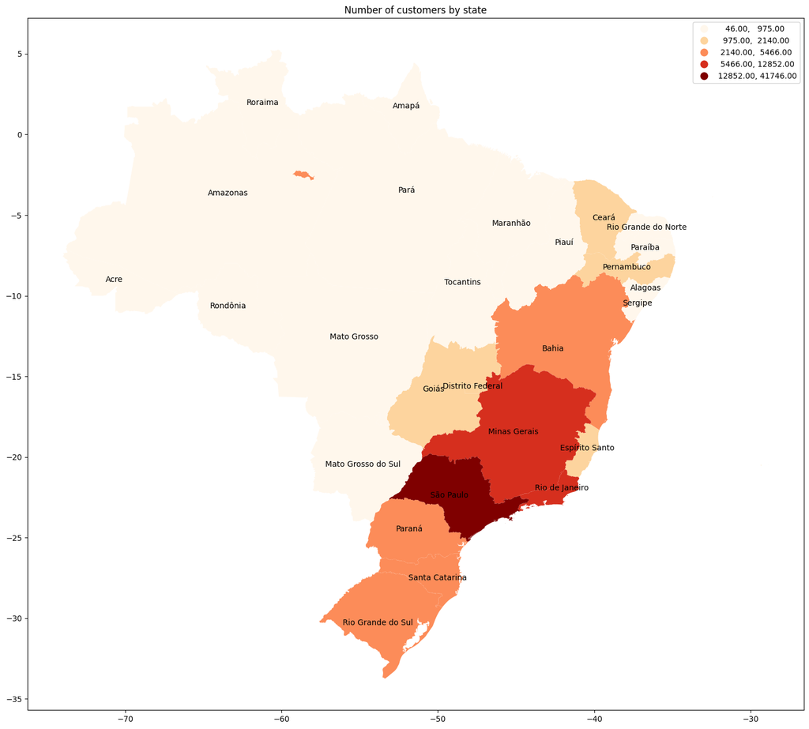

```python
#Visualizing customers by state
import matplotlib.pyplot as plt
from mpl_toolkits.axes_grid1 import make_axes_locatable
#defining the figure to create
fig, ax = plt.subplots(1, 1,figsize=(20, 16))
#Joining geometries and number of customers
customer_state = pd.DataFrame(customers.groupby("customer_state").count()["customer_id"])
location_customers=locations.merge(customer_state,left_on="STATE",right_on="customer_state")
#Defining coords for set the label on each state
location_customers["coords"] = location_customers["geometry"].apply(lambda x: x.representative_point().coords[:])
location_customers["coords"] = [coords[0] for coords in location_customers["coords"]]
#Plotting data
location_customers.plot(column='customer_id',ax=ax, cmap='OrRd', scheme='natural_breaks',
           legend=True)
ax.set_title("Number of customers by state")
for idx, row in location_customers.iterrows():
    ax.annotate(row['NAME'], xy=row["coords"], horizontalalignment="center", color="black")
```

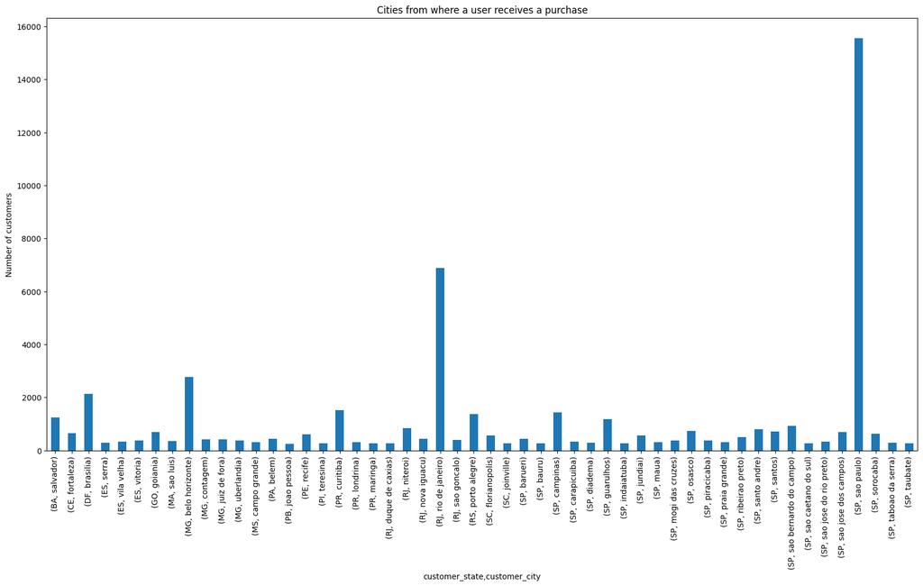

```python
#Visualizing customers by city

customers_city_state= customers.groupby(["customer_state","customer_city"]).count()
customers_city_state = customers_city_state.loc[customers_city_state["customer_id"]>250]
customers_city_state["customer_id"].plot.bar(title="Cities from where a user receives a purchase",ylabel="Number of customers",figsize=(20, 10))
```

For display purposes, cities with more than 250 customers who have received an order are selected. Additionally, Sao Paulo was observed as the city where most purchases are received, followed by Rio de Janeiro, which correspond to the most populated cities in Brazil.

### **Sellers Location**

```python
#Visualizing the sellers dataframe
sellers.head(4)
```

|  | seller_id | seller_zip_code_prefix | seller_city | seller_state |
| --- | --- | --- | --- | --- |
| 0 | 3442f8959a84dea7ee197c632cb2df15 | 13023 | campinas | SP |
| 1 | d1b65fc7debc3361ea86b5f14c68d2e2 | 13844 | mogi guacu | SP |
| 2 | ce3ad9de960102d0677a81f5d0bb7b2d | 20031 | rio de janeiro | RJ |
| 3 | c0f3eea2e14555b6faeea3dd58c1b1c3 | 4195 | sao paulo | SP |

```python
#The variables are correctly defined
sellers.dtypes
```

```
seller_id                 object
seller_zip_code_prefix     int64
seller_city               object
seller_state              object
dtype: object
```

```python
#There are no seller duplicates
sellers.seller_id.is_unique
```

```
True
```

Unlike buyers, sellers have a single location so it is possible to see their distribution directly

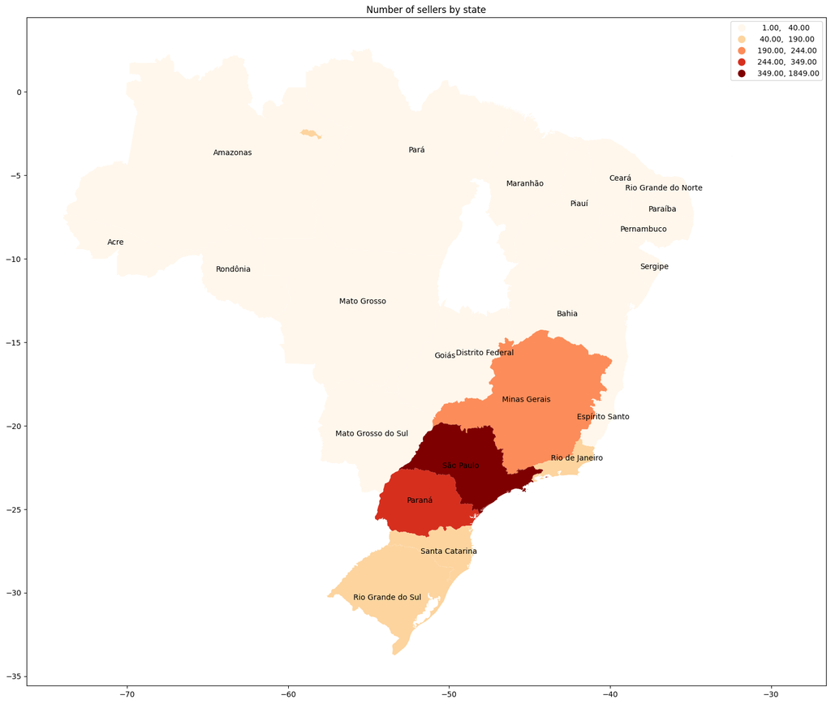

```python
#Visualizing sellers by state
import matplotlib.pyplot as plt
from mpl_toolkits.axes_grid1 import make_axes_locatable
#defining the figure to create
fig, ax = plt.subplots(1, 1,figsize=(20, 16))
#Joining geometries and number of sellers
seller_state = pd.DataFrame(sellers.groupby("seller_state").count()["seller_id"])
seller_customers=locations.merge(seller_state,left_on="STATE",right_on="seller_state")
#Defining coords for set the label on each state
seller_customers["coords"] = seller_customers["geometry"].apply(lambda x: x.representative_point().coords[:])
seller_customers["coords"] = [coords[0] for coords in seller_customers["coords"]]
#Plotting data
seller_customers.plot(column='seller_id',ax=ax, cmap='OrRd', scheme='natural_breaks',
           legend=True)
ax.set_title("Number of sellers by state")
for idx, row in seller_customers.iterrows():
    ax.annotate(row['NAME'], xy=row["coords"], horizontalalignment="center", color="black")
```

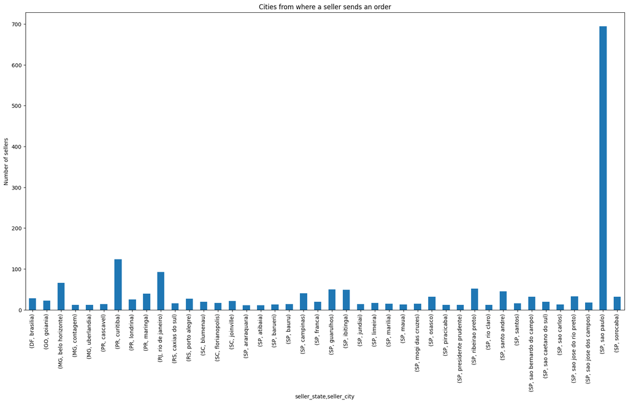

```python
#Visualizing sellers by city
sellers_city_state= sellers.groupby(["seller_state","seller_city"]).count()
sellers_city_state=sellers_city_state.loc[sellers_city_state["seller_id"]>10]
sellers_city_state["seller_id"].plot.bar(title="Cities from where a seller sends an order",ylabel="Number of sellers",figsize=(20, 10))
```

It is interesting because we also have the state of SP and the city of Sao Paulo with more sellers as well as buyers, however the second city with more sellers is Curitiba, which is also where the location of Olist.

In the previous images we could see the amount of sellers and buyers by city, but are these proportional with the population of each city? We are going to use the population data provided in this [website](https://worldpopulationreview.com/countries/cities/brazil) which contains 2022 population data by city.

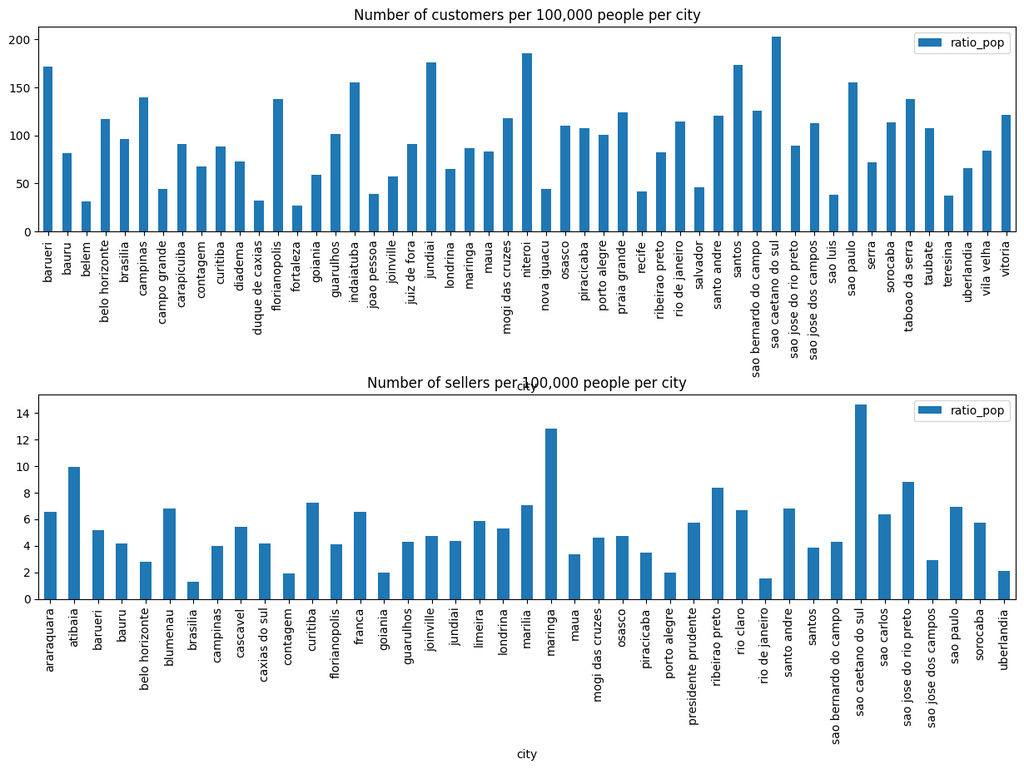

```python
pop_city=pd.read_csv("../data/population.csv")
#Left city names in lowercase to join with sellers and customers data
pop_city["city"]=pop_city["city"].str.lower()
# Joining with cities with more than 250 customers
customers_city_pop = customers_city_state.merge(pop_city,left_on="customer_city",right_on="city",how="left")
customers_city_pop.dropna(inplace=True)
#Normalizing by population
customers_city_pop["ratio_pop"]=(customers_city_pop["customer_id"]*100000)/customers_city_pop["2022"]
# Joining with the cities with more than 10 sellers
sellers_city_pop = sellers_city_state.merge(pop_city,left_on="seller_city",right_on="city",how="left")
sellers_city_pop.dropna(inplace=True)
#Normalizing by population
sellers_city_pop["ratio_pop"]=(sellers_city_pop["seller_id"]*100000)/sellers_city_pop["2022"]
#Making a graph for city vs ratio_pop
fig=plt.figure()
figsize=(20, 10)
# Setting up columns and defining cities as index
sellers_graph= sellers_city_pop[["city","ratio_pop"]]
sellers_graph.set_index("city",inplace=True)
sellers_graph.sort_index(inplace=True)
customer_graph= customers_city_pop[["city","ratio_pop"]]
customer_graph.set_index("city",inplace=True)
customer_graph.sort_index(inplace=True)
fig, axes = plt.subplots(nrows=2, ncols=1)
#Setting figure to get a better visualization
fig.set_size_inches(15.5, 10.5)
fig.tight_layout(pad=12.0)
customer_graph.plot.bar(title="Number of customers per 100,000 people per city",ax=axes[0])
ax.set_title("test")
sellers_graph.plot.bar(title="Number of sellers per 100,000 people per city",ax=axes[1])
```

By normalizing these graphs according to the population, it is observed that Sao Paulo is no longer the most representative city and that, in reality, Sao Caetano do Soul has a greater number of clients with respect to the population, as well as a greater number of sellers with respect to the population.

### First Question

Does this indicate that although it is an ecommerce, is there a relationship between the location of sellers and customers?

### **Order reviews**

Olist is a customer-oriented company and therefore the opinion of its customers is always considered, since it is the metric used to know if its services are of quality. That is why the ratings that users give to their orders are analyzed.

```python
orders_review = pd.read_csv("../data/olist_order_reviews_dataset.csv")
#Here we are going to use pandas profile to get a report of this dataframe
from pandas_profiling import ProfileReport
order_review_profile = ProfileReport(orders_review, title="Orders review Profiling Report")
order_review_profile
```

[interactive chart not shown]

In this report, we can see there are many nulls in the titles(88.3%) and in the comments(58.7%) of the ratings, which is why we decided to take only the score which does not have null values. Something important is we have a lot of 5-score, almost 58% of the ratings, and the 4-score is almost 20% of the data set.

```python
#maintaining fields with values
orders_review=orders_review.drop(columns=["review_comment_title","review_comment_message"])
#Changing score as a class instead of a number
orders_review["review_score"]=orders_review["review_score"].astype(str)
```

To get a better context about the ratings, it is necessary to add more information about the orders, such as delivery times and purchase value.

### **Orders**

The dataset of the orders is read(`orders_dataset`), which contains the order's id, the customer's id, the status of the order and some important dates such as purchase date, payment method approval date, date in that the order was delivered to the carrier, delivery date and estimated delivery date that was given to the consumer when they made the purchase. In order to perform analyzes on these data, it is important that they are in the appropriate Datetime format. Additionally, there are the order's paymens(`orders_payment`) that includes the order's id, a sequential id that indicates if there were several payment types, the payment type, installments in case of being a credit card and payment's value.

```python
#Reading data and visualize data types for each dataframe
orders_dataset = pd.read_csv("../data/olist_orders_dataset.csv")
orders_payment = pd.read_csv("../data/olist_order_payments_dataset.csv")
display("Orders",orders_dataset.dtypes)
display("Orders payments",orders_payment.dtypes)
display("Orders: Missing values",orders_dataset.isna().sum())
display("Orders payments: Missing values",orders_payment.isna().sum())
display("Orders: Total values",orders_dataset.shape[0])
display("Orders payments: Total values",orders_payment.shape[0])
```

```
'Orders'
```

```
order_id                         object
customer_id                      object
order_status                     object
order_purchase_timestamp         object
order_approved_at                object
order_delivered_carrier_date     object
order_delivered_customer_date    object
order_estimated_delivery_date    object
dtype: object
```

```
'Orders payments'
```

```
order_id                 object
payment_sequential        int64
payment_type             object
payment_installments      int64
payment_value           float64
dtype: object
```

```
'Orders: Missing values'
```

```
order_id                            0
customer_id                         0
order_status                        0
order_purchase_timestamp            0
order_approved_at                 160
order_delivered_carrier_date     1783
order_delivered_customer_date    2965
order_estimated_delivery_date       0
dtype: int64
```

```
'Orders payments: Missing values'
```

```
order_id                0
payment_sequential      0
payment_type            0
payment_installments    0
payment_value           0
dtype: int64
```

```
'Orders: Total values'
```

```
99441
```

```
'Orders payments: Total values'
```

```
103886
```

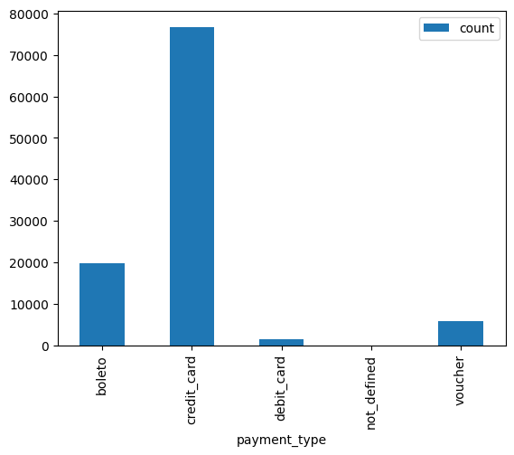

```python
# Make a graph with payments type distribution
orders_payment.groupby(['payment_type']).count().reset_index()[["payment_type", "order_id"]].rename(columns={"order_id":"count"}).plot.bar(x="payment_type")
```

Most of the transactions are made using credit card, what is expected for an ecommerce store. On the other hand, there are null values for some dates such as the date of delivery to the customer and the date on which it passed to the carrier, but there are around 3000 values (the one with the most missing values), with respect to 99441 observations, so it is possible to carry out a general analysis of that values.

```python
#changing strings to datetimes
orders_dataset["order_purchase_timestamp"] = pd.to_datetime(orders_dataset["order_purchase_timestamp"])
orders_dataset["order_approved_at"] = pd.to_datetime(orders_dataset["order_approved_at"])
orders_dataset["order_delivered_carrier_date"] = pd.to_datetime(orders_dataset["order_delivered_carrier_date"])
orders_dataset["order_delivered_customer_date"] = pd.to_datetime(orders_dataset["order_delivered_customer_date"])
orders_dataset["order_estimated_delivery_date"] = pd.to_datetime(orders_dataset["order_estimated_delivery_date"])
```

```python
#The idea is to analyze the behavior of the sales process, for this we only require orders that have already been delivered.
orders_delivered=orders_dataset.loc[orders_dataset["order_status"]=='delivered'].copy()
display("shape before",orders_delivered.shape)
display(orders_delivered.isna().sum())
#Because we have just a few values missing we are goint to remove them taking account those observations represent 0.02% of the data
orders_delivered.dropna(inplace=True)
display("shape after",orders_delivered.shape)
```

```
'shape before'
```

```
(96478, 8)
```

```
order_id                          0
customer_id                       0
order_status                      0
order_purchase_timestamp          0
order_approved_at                14
order_delivered_carrier_date      2
order_delivered_customer_date     8
order_estimated_delivery_date     0
dtype: int64
```

```
'shape after'
```

```
(96455, 8)
```

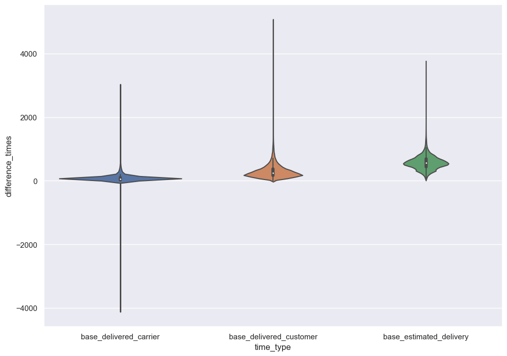

```python
#If we take the purchase timestamp as our baseline to define the times of the entire sales process, we can get an idea of the general behavior
orders_delivered["base_approved"]=(orders_dataset["order_approved_at"] - orders_dataset["order_purchase_timestamp"])/pd.Timedelta('1h')
orders_delivered["base_delivered_carrier"]=(orders_dataset["order_delivered_carrier_date"] - orders_dataset["order_purchase_timestamp"])/pd.Timedelta('1h')
orders_delivered["base_delivered_customer"]=(orders_dataset["order_delivered_customer_date"] - orders_dataset["order_purchase_timestamp"])/pd.Timedelta('1h')
orders_delivered["base_estimated_delivery"]=(orders_dataset["order_estimated_delivery_date"] - orders_dataset["order_purchase_timestamp"])/pd.Timedelta('1h')
orders_delivered["estimated_delivery_delivered_customer"]=(orders_dataset["order_estimated_delivery_date"] - orders_dataset["order_delivered_customer_date"])/pd.Timedelta('1h')
#Make a graph to see the time differences
orders_delivered_melt = orders_delivered.melt(id_vars=['order_id'], value_vars=["base_delivered_carrier","base_delivered_customer","base_estimated_delivery"],
        var_name='time_type', value_name='difference_times')
sns.set(rc={'figure.figsize':(11.7,8.27)})

sns.violinplot(data=orders_delivered_melt, x="time_type", y="difference_times")
```

In the graph above it is possible to see the time differences between the date the purchase is made with: The date the carrier receives the order, the date it is delivered to the customer, and the date the customer is promised delivery, but there is something strange, there are negative values between the date that it was delivered to the carrier and the pruchase'sdate. Let's look at the following records:

```python
orders_delivered.loc[orders_delivered["base_delivered_carrier"]<-100][["order_purchase_timestamp","order_delivered_carrier_date","base_delivered_carrier"]]
```

|  | order_purchase_timestamp | order_delivered_carrier_date | base_delivered_carrier |
| --- | --- | --- | --- |
| 25883 | 2018-07-16 18:40:53 | 2018-01-26 13:35:00 | -4109.098056 |
| 83321 | 2018-08-18 11:49:40 | 2018-08-14 06:22:00 | -101.461111 |

Is there any sense that the purchase was made on 2018-07-16 but the carrier received it on 2018-01-26? This means that we have errors in the data, which is why, in order not to increase the bias of the data to these values that are less than zero, we are going to assign them the same purchase time, taking into account that in the distribution these dates tend to be similar.

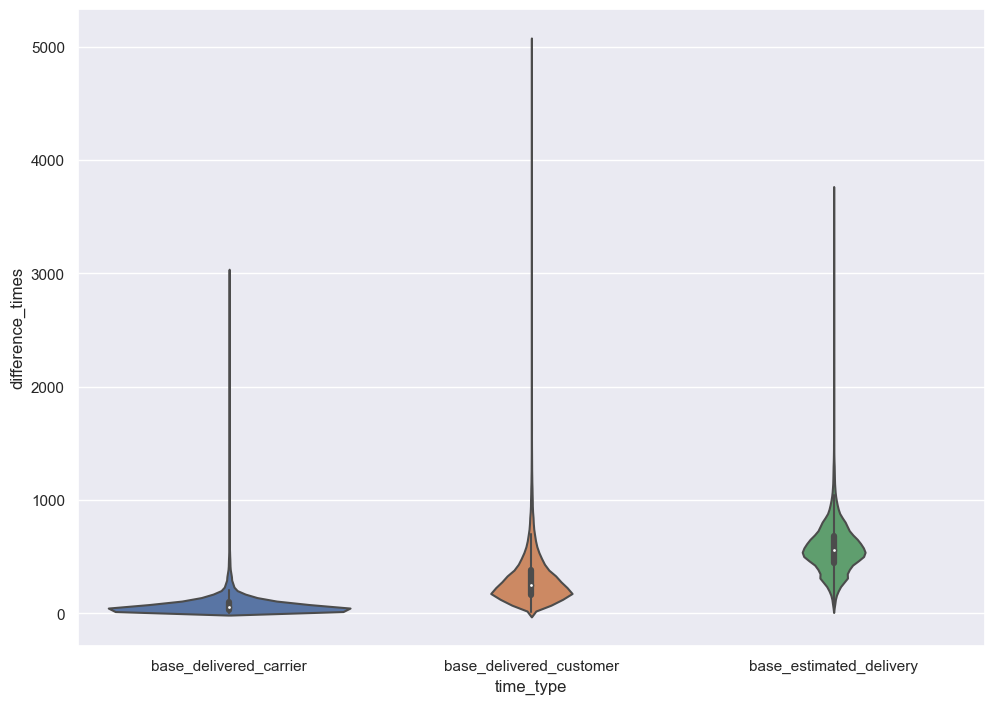

```python
orders_delivered.loc[orders_delivered["base_delivered_carrier"]<0,"base_delivered_carrier"]=0
#Make a graph to see the time differences
orders_delivered_melt = orders_delivered.melt(id_vars=['order_id'], value_vars=["base_delivered_carrier","base_delivered_customer","base_estimated_delivery"],
        var_name='time_type', value_name='difference_times')
sns.violinplot(data=orders_delivered_melt, x="time_type", y="difference_times")
```

There are still some outliers in the data, but does this mean it is good or bad? let's review what was the estimated delivery time vs the delivery time

```
[Text(0.5, 1.0, 'Difference between Estimated deliver time and Delivered time (Hours)')]
```

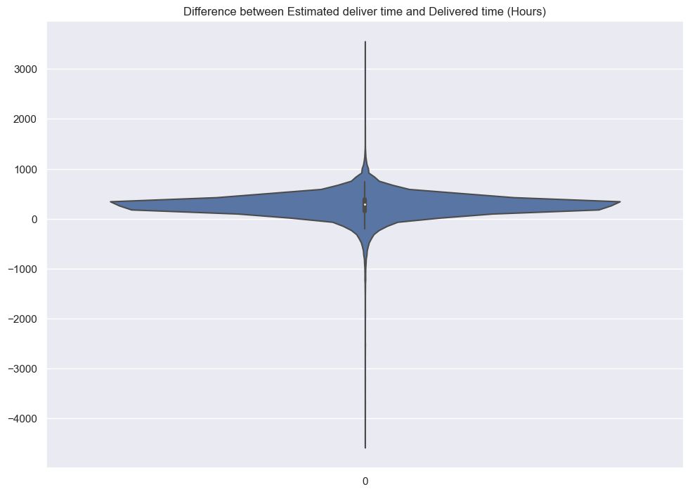

```python
#Make a graph to see the time differences
sns.violinplot(data=orders_delivered["estimated_delivery_delivered_customer"]).set(title='Difference between Estimated deliver time and Delivered time (Hours)')
```

It is observed that the times tend to be positive, which means that in general the estimated delivery time is greater than the actual delivery time. Those who are superior outliers are not so alarming since they are those customers who received their delivery much earlier than the estimated. However, those extreme negative values show that there are others that were delivered much later than expected.

### Second Question

Is it possible that there is a relationship between purchase times, purchase value and customer rating?

## **Model**

### Question 1

is there a relationship between the location of sellers and customers?

```python
#Including data to relate customers and sellers
order_items = pd.read_csv("../data/olist_order_items_dataset.csv")
```

```python
#Joining customers and sellers through the order id
sellers_customers=orders_dataset.loc[orders_dataset["order_status"]=="delivered",["order_id","customer_id"]].merge(order_items[["order_id","seller_id"]]).drop_duplicates()
```

```python
## Adding seller and customers location
# For these joins we are going to leave the default behavior which is inner, because we need the rows that have both values.
# This was analyzed before and we didn't have missing data.
sellers_customers=sellers_customers.merge(sellers[["seller_state","seller_id"]])
#We are using the customer id instead of the unique id because how we defined before each unique has a different location but for this analysis we are assuming each row as a new customer to include all the possible locations for each customer.
sellers_customers=sellers_customers.merge(customers[["customer_id","customer_state"]])
```

```python
order_states = sellers_customers.groupby(["seller_state","customer_state"]).agg({"order_id":"count"}).reset_index()
```

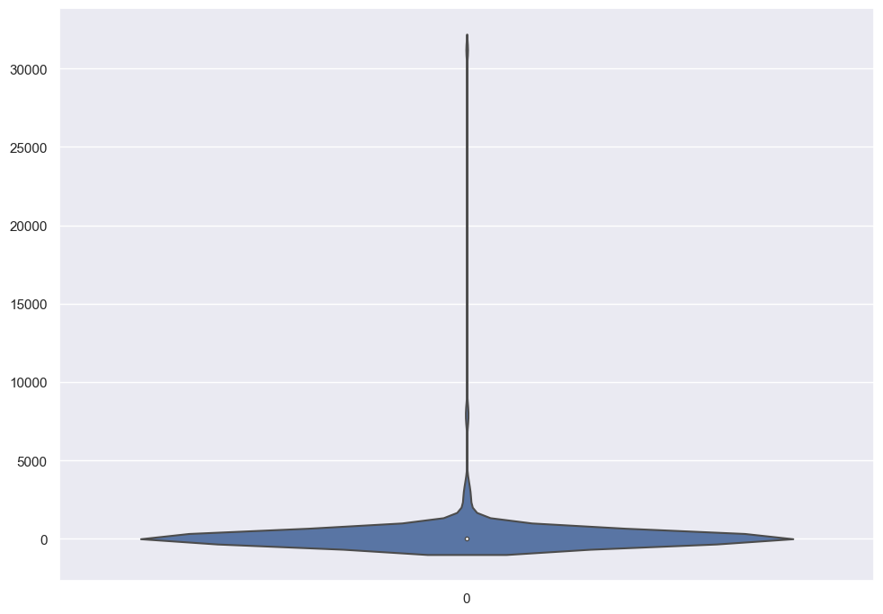

```python
sns.violinplot(order_states["order_id"])
```

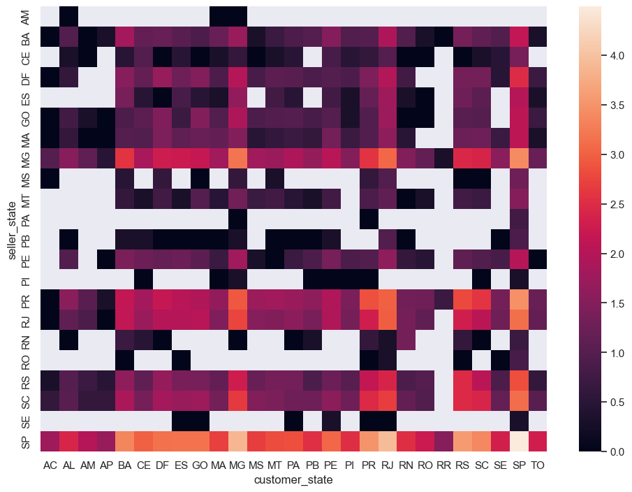

```python
#As we have a large range we can use a logarithmic scale to show the relation between seller and customer states
from math import log10
order_states["log_order_id"] =order_states["order_id"].apply(log10)
sns.heatmap(order_states.pivot("seller_state", "customer_state", "log_order_id"))
```

### Answer 1

It seems there is no a clear correlation between seller and customer state. Sao Paulo stand outs both as seller and customer state. Sellers from diverse states are competing for the countrywide market.

This makes the delivery time an important point to discuss, as stated in question 2.

### Question 2

Is it possible that there is a relationship between purchase times, purchase value and customer rating?

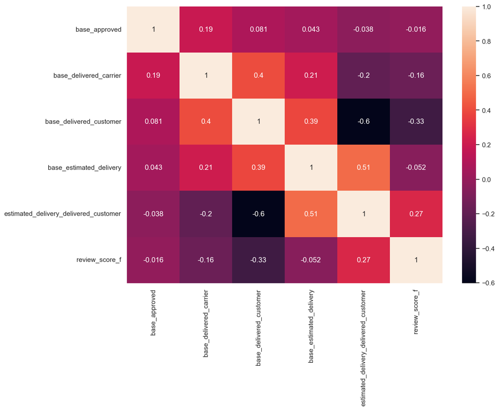

```python
#Showing relationship between variables
rscore_time = orders_review.merge(orders_delivered)[["review_score", 'base_approved', 'base_delivered_carrier', 'base_delivered_customer',
       'base_estimated_delivery', 'estimated_delivery_delivered_customer' ]]
rscore_time["review_score_f"] = rscore_time["review_score"].astype("float")
sns.heatmap(rscore_time.corr(), annot=True)
```

There are two important conclusions from this plot:

```
  1. There is a negative correlation between the delivery time and the user satisfaction.

  2. There is a positive correlation between the difference between the estimated and the actual delivery time.
```

A hypothesis can be drawn from here: a better delivery time estimate can improve the customer satisfaction.

```python
#Note: product characteristics are assumed to be encoded in the seller and the freight value.
grouped_order_items = order_items.groupby(["order_id","seller_id"]).agg({"price":"sum", "product_id":"count", "freight_value":"sum"}).reset_index()
```

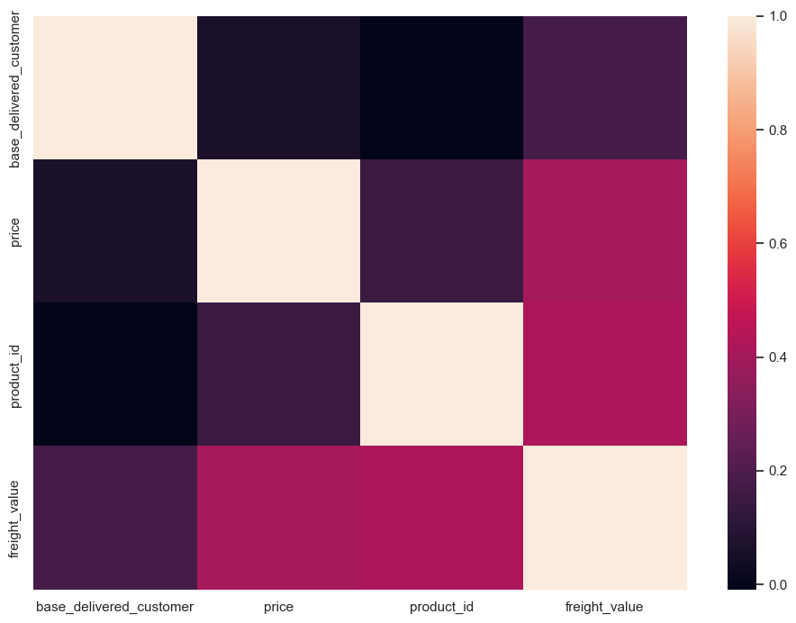

```python
# In this case we keep the seller id as a the seller internal processes can influence the delivery time.
orig_dataset=orders_delivered[["base_delivered_customer","order_id"]].merge(grouped_order_items).merge(sellers_customers).drop(columns=["order_id", "customer_id"])
sns.heatmap(orig_dataset.corr())
```

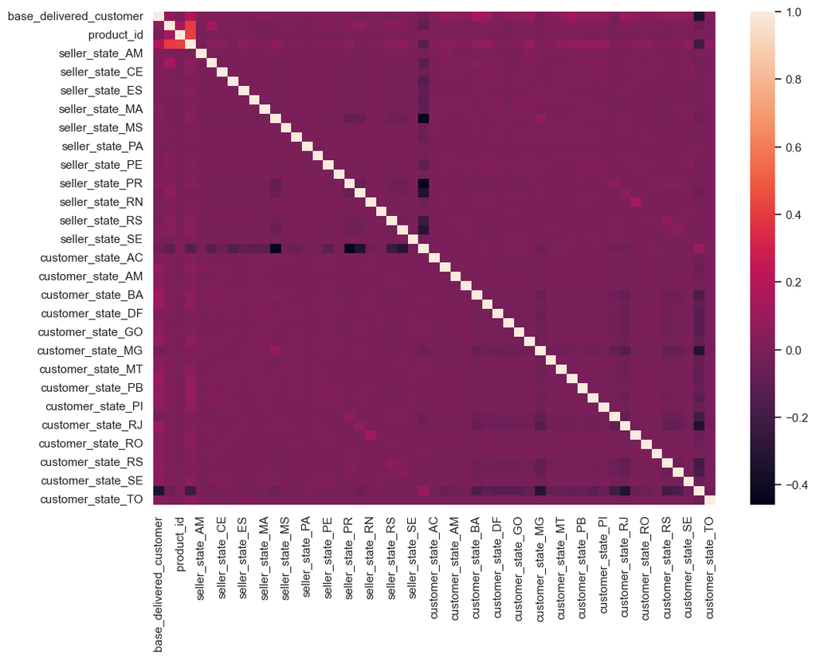

```python
#Including customer and seller location
sns.heatmap(pd.get_dummies(orig_dataset.drop(columns=["seller_id"])).corr())
```

```python
#The seller is important to determine behavior implicit by each seller. In this case, we are using a label encoder instead of dummy variables to reduce the complexity of the model.
from sklearn import preprocessing
label_encoder_seller = preprocessing.LabelEncoder()
label_encoder_seller.fit(orig_dataset.seller_id)
orig_dataset["seller_id_enc"] = label_encoder_seller.transform(orig_dataset.seller_id)
##Generating fuinal dataset to create model
dataset_t = pd.get_dummies(orig_dataset.drop(columns=["seller_id"]))
#Removing high outliers, there are no reason to have more than 2000 hours to delivery an specific item.
dataset_t= dataset_t.loc[dataset_t.base_delivered_customer<2000]
```

```python
from sklearn.ensemble import RandomForestRegressor
from sklearn.model_selection import cross_val_score
from sklearn.preprocessing import StandardScaler
#Scaling data and defining independent and dependent variables
scaler = StandardScaler()
target="base_delivered_customer"
X = dataset_t.drop(columns=[target])
scaler.fit(X)
X = scaler.transform(X)
y = dataset_t[target]
```

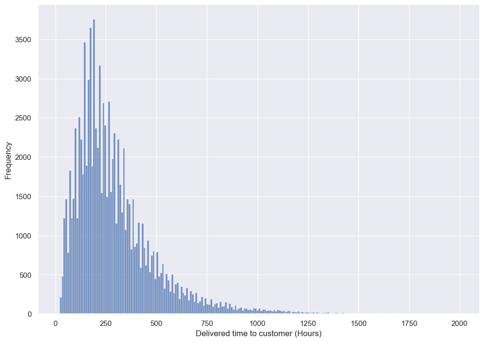

```python
##Distribution of target variable
ax = sns.histplot(dataset_t.base_delivered_customer)
ax.set(xlabel='Delivered time to customer (Hours)', ylabel='Frequency')
plt.show()
```

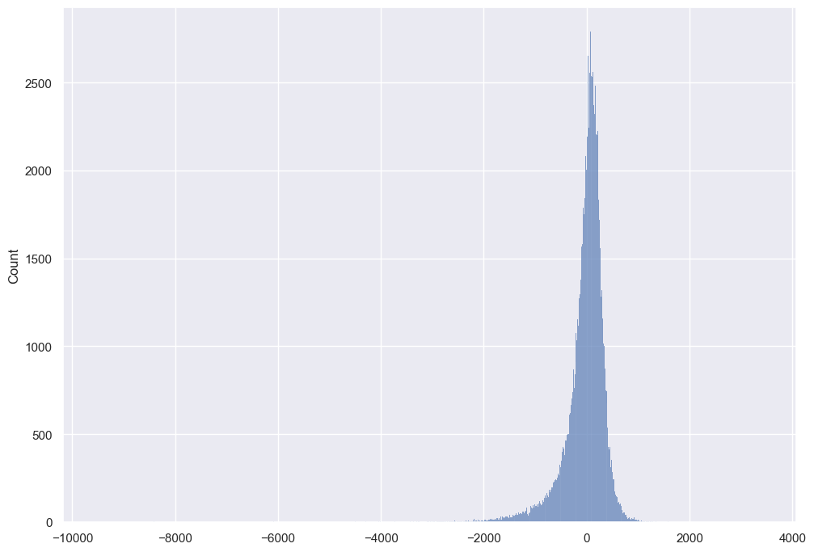

```python
#Showing the difference between estimated times and actual delivery times
sns.histplot(orders_delivered.estimated_delivery_delivered_customer-orders_delivered.base_delivered_customer)
```

It is important to see that currently the distribution of the time difference between the estimated time of the purchase and the time in which the product was delivered. This will allow us to compare the results of the models proposed taking into account the delivery data.The values oscilated between -9535 and 3418

### KNeighbors

```python
from sklearn.neighbors import KNeighborsRegressor
#Defining K
error_rate = []
for i in range(1,100,5):
    knn = KNeighborsRegressor(n_neighbors=i)
    knn.fit(X,y)
    pred_i = knn.predict(X)
    error_rate.append(-cross_val_score(knn, X, y, cv=10,scoring= 'neg_root_mean_squared_error').mean())
```

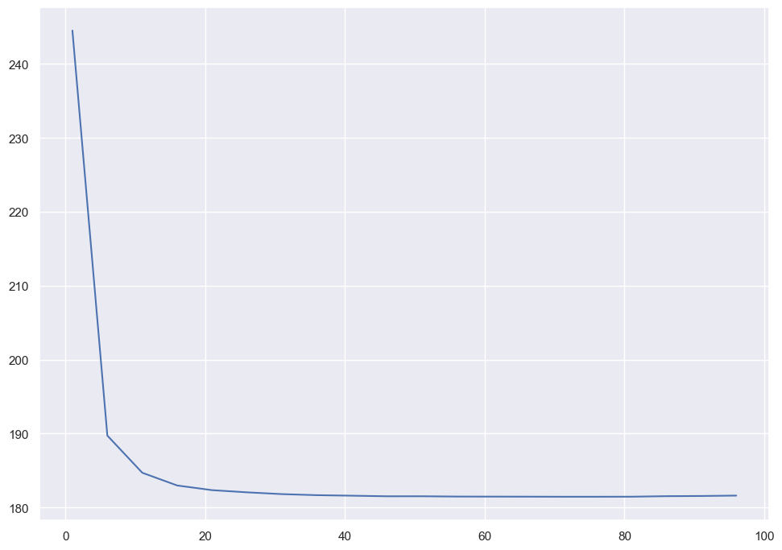

```python
#Getting better K to model
sns.lineplot(x=range(1,100,5), y=error_rate)
```

```python
#Using better K based on previous Graph
from sklearn.neighbors import KNeighborsRegressor
regr = KNeighborsRegressor(n_neighbors=15)
##Getting rmse for each fold
cross_val_score(regr, X, y, cv=10,scoring= 'neg_root_mean_squared_error')
```

```
array([-183.53965948, -184.00820862, -181.05569141, -180.13306799,
       -183.22288605, -183.34437028, -183.47975409, -182.41792475,
       -188.51680134, -182.15439488])
```

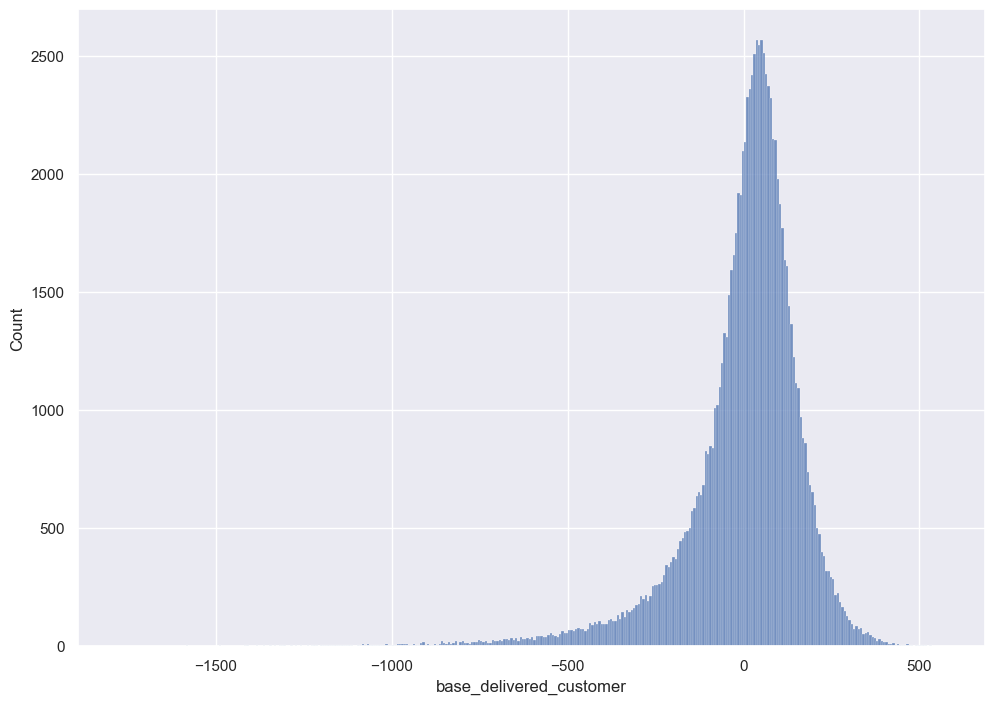

```python
regr.fit(X,y)
#Distribution between differences from Predicted and actual values
sns.histplot(regr.predict(X)-y)
```

In the last graph, we can see there are big true values greater than theirs predictions, and that the differences oscillate between -1775 and 567 hours.

### Lasso

```python
from sklearn import linear_model
import numpy as np
#Defining better alpha
error_rate_alpha = []
for i in np.arange(0.0,1.0,0.1):
    clf = linear_model.Lasso(alpha=i)
    clf.fit(X,y)
    clf_i = clf.predict(X)
    error_rate_alpha.append(-cross_val_score(clf, X, y, cv=10,scoring= 'neg_root_mean_squared_error').mean())
```

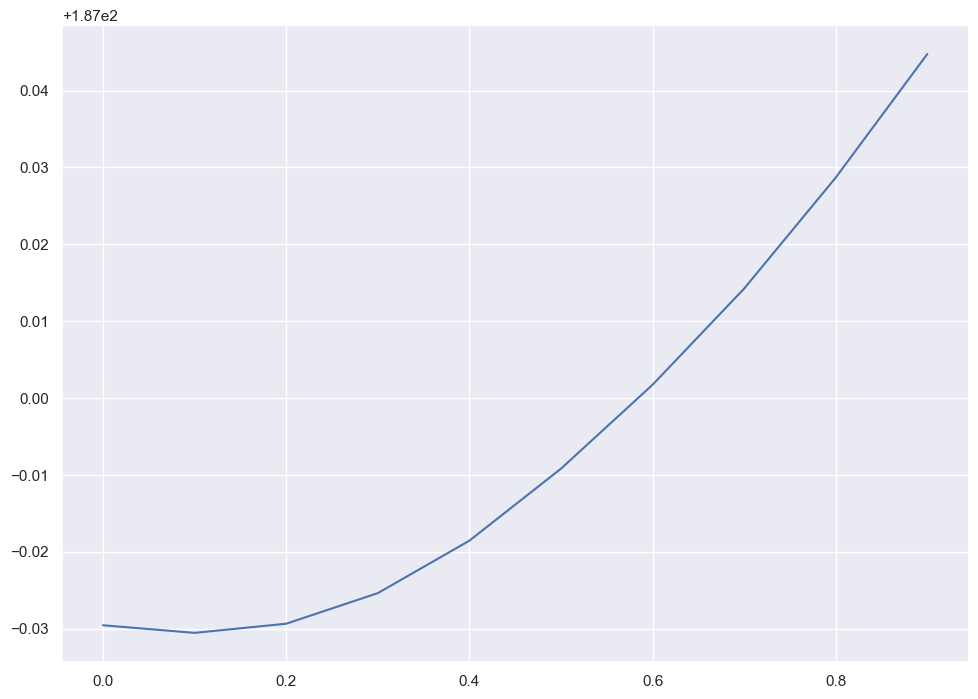

```python
#Getting better alpha to model
sns.lineplot(x=np.arange(0.0,1.0,0.1), y=error_rate_alpha)
```

```python
clf = linear_model.Lasso(alpha=0.1)
##Getting rmse for each fold
cross_val_score(clf, X, y, cv=10,scoring= 'neg_root_mean_squared_error')
```

```
array([-186.55442102, -188.13532602, -185.38760278, -183.59172968,
       -187.91146203, -185.97658646, -186.99953442, -186.79473693,
       -192.13146013, -186.21168646])
```

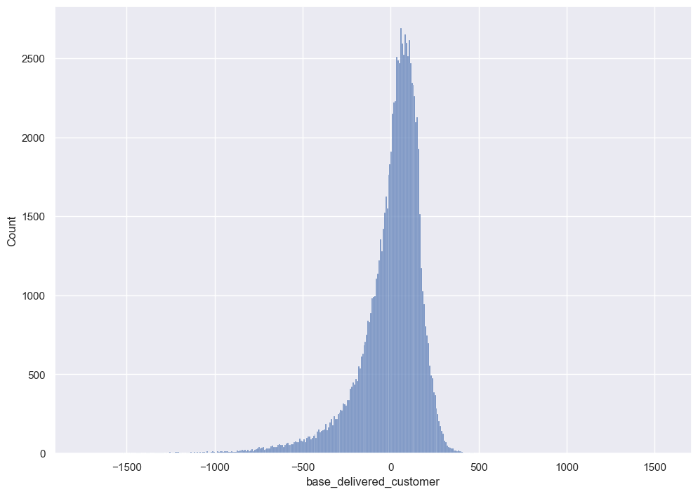

```python
clf.fit(X,y)
#Distribution between differences from Predicted and actual values
sns.histplot(clf.predict(X)-y)
```

In the last graph, we see a similiar behavior with the KNN Model, there are big true values greater than theirs predictions, and that the differences oscillate between -1744 and 1543 hours.

### Conclusion

Although it is possible to obtain a model that predicts the estimated time, to obtain a better model it is necessary to have more associated variables such as transport companies, weather data, more detail of the locations, data associated with the purchase season, and more.

As defined by [statista](https://www.statista.com/statistics/1117196/delivery-time-e-commerce-brazil/) the average delivery time for online orders is approximately 21 days, that is, approximately 504 hours. Additionally, the two models used previously show a similar behavior, leaving errors of approximately 190 hours, which is still a time with too much uncertainty, but when compared with the dataset times that have deliveries of up to more than 5000 hours, it is not so away.

Although the KNN model has a similar error to the Lasso model, the difference between the actual values and the predicted values are smaller, that is why it could work better for this problem, taking into account that either of the two models improves the behavior of estimated times and actual delivery times.

However, more precision is required to achieve the objective of giving the user more tools to decide whether to make a purchase or not.